# Case Study 2

W Holt, Y Kunwar, J Lancon, J Lubich

December 04, 2017

### Project Name: EDA - Attrition Data Analysis

### Client: DDSAnalytics

#### Project Description: Preliminary Exploratory Data Analysis - (Employee Retention)

##### GitHub Repository: https://github.com/jlubich/DDS-CASE-STUDY-2

## Introduction

DDSAnalytics is an analytic company that specializes in talent management solutions for Fortune 1000 companies. Having access to valuable demographic information obtained from employee’s personnel files and workplace environmental data (Employee Surveys), DDSAnalytics executive management is interested leveraging this wealth of data, to provide additional services to their client base and assist them in improving their talent management strategies.  
DDSAnalytics’ management understands the key role an excellent talent management system play in the development of any company. Untold amounts of money and resources are spent hiring, training, and developing the most valuable asset a company has; Their Employees. The path is fraught with missteps, from hiring the ‘wrong fit’ personnel, not identifying and nurturing young talent, loss of productivity due to inexperienced personnel and lower profits due to excessive expenses associated with recruiting new employees.  
**Purpose:** Through the use of Data Science, DDSAnalytics identified an opportunity to gain a competitive edge by helping their clients better manage their talent. Before management green lights the development of the data science department, they have tasked the data science(DS) team to conduct an analysis of existing employee data. The executive leadership has identified predicting employee turnover as its first application for the data science initiative. The DS team was presented an existing data-set, to conduct an exploratory data analysis (EDA), to determine factor that leads to employee attrition. The major objectives are as follows:

- Identify and discuss the top factors that contribute to employee attrition.
- Determine if any job role specific trends that may exist.
- Identify any interesting trends and/or observations
- Determine Next-Steps in EDA process.

**Dataset**

- **Client Dataset:** The DS team was presented with an anonymous client’s employee data-set. Certain identifiable information was removed from the data-set (employee names, company name, etc.). The data-set contains 35 variables with 1470 observations. The variables captured both employee data (age, sex, tenure, position, wages, performance reviews, education,…) as well as workplace environmental data (Job involvement, job satisfaction, work/life balance, travel%,…), which provides a more complete picture of the workers and their environment.  
  **Dataset:** CaseStudy2Data.csv

#### **Data Visualization/Exploration:**

The first step in the analysis process is to load the data-set and review its contents. The best methods for this are visually looking at the data.

**Table 1.1 Variables - Classifications/Observations:** contains the variable name, variable class, and first 10 observations.**

**Fig 1.1** (Variables - Classifications/Observations)

```r
##############################################################################
## 1 - Explore the available data and clean as necessary
##############################################################################


## Load up the Talent Data
TalentData <- read.csv("./DATA/casestudy2-data.csv")
HR <- TalentData
## Review basic summary of data contents
str(TalentData)
```

```
## 'data.frame':    1470 obs. of  35 variables:
##  $ ï..Age                  : int  41 49 37 33 27 32 59 30 38 36 ...
##  $ Attrition               : Factor w/ 2 levels "No","Yes": 2 1 2 1 1 1 1 1 1 1 ...
##  $ BusinessTravel          : Factor w/ 3 levels "Non-Travel","Travel_Frequently",..: 3 2 3 2 3 2 3 3 2 3 ...
##  $ DailyRate               : int  1102 279 1373 1392 591 1005 1324 1358 216 1299 ...
##  $ Department              : Factor w/ 3 levels "Human Resources",..: 3 2 2 2 2 2 2 2 2 2 ...
##  $ DistanceFromHome        : int  1 8 2 3 2 2 3 24 23 27 ...
##  $ Education               : int  2 1 2 4 1 2 3 1 3 3 ...
##  $ EducationField          : Factor w/ 6 levels "Human Resources",..: 2 2 5 2 4 2 4 2 2 4 ...
##  $ EmployeeCount           : int  1 1 1 1 1 1 1 1 1 1 ...
##  $ EmployeeNumber          : int  1 2 4 5 7 8 10 11 12 13 ...
##  $ EnvironmentSatisfaction : int  2 3 4 4 1 4 3 4 4 3 ...
##  $ Gender                  : Factor w/ 2 levels "Female","Male": 1 2 2 1 2 2 1 2 2 2 ...
##  $ HourlyRate              : int  94 61 92 56 40 79 81 67 44 94 ...
##  $ JobInvolvement          : int  3 2 2 3 3 3 4 3 2 3 ...
```

[output cut: 21 more lines]

**Table 1.2 Summary Statistics:** contains statistical summaries of each category (mean, median, min/max, etc.). This give the team a high-level understanding of what is included in the data-set.**

**Figure 1.2** (Summary Statistics)

```r
SumTalentData <- summary(TalentData)
print(SumTalentData)
```

```
##      ï..Age      Attrition            BusinessTravel   DailyRate
##  Min.   :18.00   No :1233   Non-Travel       : 150   Min.   : 102.0
##  1st Qu.:30.00   Yes: 237   Travel_Frequently: 277   1st Qu.: 465.0
##  Median :36.00              Travel_Rarely    :1043   Median : 802.0
##  Mean   :36.92                                       Mean   : 802.5
##  3rd Qu.:43.00                                       3rd Qu.:1157.0
##  Max.   :60.00                                       Max.   :1499.0
##
##                   Department  DistanceFromHome   Education
##  Human Resources       : 63   Min.   : 1.000   Min.   :1.000
##  Research & Development:961   1st Qu.: 2.000   1st Qu.:2.000
##  Sales                 :446   Median : 7.000   Median :3.000
##                               Mean   : 9.193   Mean   :2.913
##                               3rd Qu.:14.000   3rd Qu.:4.000
##                               Max.   :29.000   Max.   :5.000
##
##           EducationField EmployeeCount EmployeeNumber
##  Human Resources : 27    Min.   :1     Min.   :   1.0
##  Life Sciences   :606    1st Qu.:1     1st Qu.: 491.2
##  Marketing       :159    Median :1     Median :1020.5
##  Medical         :464    Mean   :1     Mean   :1024.9
##  Other           : 82    3rd Qu.:1     3rd Qu.:1555.8
##  Technical Degree:132    Max.   :1     Max.   :2068.0
##
##  EnvironmentSatisfaction    Gender      HourlyRate     JobInvolvement
##  Min.   :1.000           Female:588   Min.   : 30.00   Min.   :1.00
##  1st Qu.:2.000           Male  :882   1st Qu.: 48.00   1st Qu.:2.00
##  Median :3.000                        Median : 66.00   Median :3.00
##  Mean   :2.722                        Mean   : 65.89   Mean   :2.73
##  3rd Qu.:4.000                        3rd Qu.: 83.75   3rd Qu.:3.00
##  Max.   :4.000                        Max.   :100.00   Max.   :4.00
##
##     JobLevel                          JobRole    JobSatisfaction
##  Min.   :1.000   Sales Executive          :326   Min.   :1.000
##  1st Qu.:1.000   Research Scientist       :292   1st Qu.:2.000
##  Median :2.000   Laboratory Technician    :259   Median :3.000
##  Mean   :2.064   Manufacturing Director   :145   Mean   :2.729
##  3rd Qu.:3.000   Healthcare Representative:131   3rd Qu.:4.000
##  Max.   :5.000   Manager                  :102   Max.   :4.000
##                  (Other)                  :215
```

[output cut: 25 more lines]

```
##  Min.   :0.000         Min.   :1.000   Min.   : 0.000   Min.   : 0.000
##  1st Qu.:2.000         1st Qu.:2.000   1st Qu.: 3.000   1st Qu.: 2.000
##  Median :3.000         Median :3.000   Median : 5.000   Median : 3.000
##  Mean   :2.799         Mean   :2.761   Mean   : 7.008   Mean   : 4.229
##  3rd Qu.:3.000         3rd Qu.:3.000   3rd Qu.: 9.000   3rd Qu.: 7.000
##  Max.   :6.000         Max.   :4.000   Max.   :40.000   Max.   :18.000
##
##  YearsSinceLastPromotion YearsWithCurrManager
##  Min.   : 0.000          Min.   : 0.000
##  1st Qu.: 0.000          1st Qu.: 2.000
##  Median : 1.000          Median : 3.000
##  Mean   : 2.188          Mean   : 4.123
##  3rd Qu.: 3.000          3rd Qu.: 7.000
##  Max.   :15.000          Max.   :17.000
##
```

A quick review of the summary data tables above shows some basic statistics about the company and it’s employees.

- **Attrition:** 237 of 1470 = **16.1%**
- **Gender:** M 882 : F 588 60%:40% split
- **Age Range:** 18 to 60 with median of 36 yrs old
- **Years of Tenure:** 0 to 40 yrs with median of 5.0 yrs
- **Type of Organization:** Professional Company; Research & Development and Sales Roles dominating the ranks

With just this initial data, it is possible to begin to draw a picture of the company and it’s employees.

#### **Data Cleaning & Manipulation**

**Data Cleaning:**  
After reviewing the original data-set, the data appears very well organized and complete, with very few missing observations.

```r
## Fix Garbled Column Name
names(TalentData)[1] <- "Age"
```

**Data Manipulation/Munging:**  
One new column has been derived to transform the Yes/No values of attrition into a count which we can use for further analysis and visualizations.

```r
## Recode Attrition flag for counting
TalentData$AttritionCount <- ifelse(TalentData$Attrition=="Yes",1,0)
```

**Data Catagorization:**  
The data-set contains variables that are categorical in nature. They appear to be excerpts from employee surveys and/or personnel performance reviews. These variables are numerically rankings based (1,2,3,4) where 1 = Low, 2 = Med, etc.. A legend of what each categorical variable ranking means was included in the data-set.  
While this format is good data entry and manipulation, it is not ‘human readable’ and not very informative; therefore, the team has manipulated the data-set to display the ‘human readable’ variable format. We created a new variable for each categorical variable transformed and labeled it with suffix *‘VariableName’*.Label.

```r
## Map numerical flags to Categorical Labels
TalentData$Education.Label <- plyr::mapvalues(
  TalentData$Education,
  from = c(1,2,3,4,5),
  to = c("Below College", "College", "Bachelor", "Master", "Doctor")
)

TalentData$EnvironmentSatisfaction.Label <- plyr::mapvalues(
  TalentData$EnvironmentSatisfaction,
  from = c(1,2,3,4),
  to = c("Low", "Medium", "High", "Very High")
)

TalentData$JobInvolvement.Label <- plyr::mapvalues(
  TalentData$JobInvolvement,
  from = c(1,2,3,4),
  to = c("Low", "Medium", "High", "Very High")
)

TalentData$JobSatisfaction.Label <- plyr::mapvalues(
  TalentData$JobSatisfaction,
  from = c(1,2,3,4),
  to = c("Low", "Medium", "High", "Very High")
)

TalentData$PerformanceRating.Label <- plyr::mapvalues(
  TalentData$PerformanceRating,
  from = c(1,2,3,4),
  to = c("Low", "Good", "Excellent", "Outstanding")
)
TalentData$RelationshipSatisfaction.Label <- plyr::mapvalues(
  TalentData$RelationshipSatisfaction,
  from = c(1,2,3,4),
  to = c("Low", "Medium", "High", "Very High")
)

TalentData$WorkLifeBalance.Label <- plyr::mapvalues(
  TalentData$WorkLifeBalance,
  from = c(1,2,3,4),
  to = c("Bad", "Good", "Better", "Best")
)
```

**Data Binning:**  
Several variables have either continuous numerical data (Income, travel distance,..) or numerous discrete values (age,..). To better visualize, reduce clutter, and interpret the data interpret, the team created Bins/Data-Ranges for these variables.We created a new variable for each categorical variable transformed and labeled it with suffix *‘VariableName’*.Bin

```r
# Age Bins#
# set up boundaries for intervals/bins
breaks <- c(0,25,35,45,55,65,Inf)
# specify interval/bin labels
labels <- c("18-24", "25-34", "35-44", "45-54", "55-64", "65+")
# bucketing data points into bins
TalentData$Age.Bin <- cut(TalentData$Age, breaks, include.lowest = T, right=FALSE, labels=labels)


# Distance-from-Home Bins#
# set up boundaries for intervals/bins
breaks <- c(0,5,10,15,20,25,30,35,40,Inf)
# specify interval/bin labels
labels <- c("0-4", "5-9", "10-14", "15-19", "20-24", "25-29", "30-34", "35-39", "40+")
# bucketing data points into bins
TalentData$DistanceFromHome.Bin <- cut(TalentData$DistanceFromHome, breaks, include.lowest = T, right=FALSE, labels=labels)


# Years at Company Bins#
# set up boundaries for intervals/bins
breaks <- c(0,3,6,11,21,Inf)
# specify interval/bin labels
labels <- c("0-1", "2-5", "6-10", "11-20", "20+")
# bucketing data points into bins
TalentData$YearsAtCompany.Bin <- cut(TalentData$YearsAtCompany, breaks, include.lowest = T, right=FALSE, labels=labels)


# Total-Working-Years Bins#
# set up boundaries for intervals/bins
breaks <- c(0,3,6,11,21,Inf)
# specify interval/bin labels
labels <- c("0-1", "2-5", "6-10", "11-20", "20+")
# bucketing data points into bins
TalentData$TotalWorkingYears.Bin <- cut(TalentData$TotalWorkingYears, breaks, include.lowest = T, right=FALSE, labels=labels)


# Monthly-Rate Bins#
# set up boundaries for intervals/bins
breaks <- c(0,5000,10000,15000,20000,25000,Inf)
# specify interval/bin labels
labels <- c("0-5000", "5001-10000","10001-15000","15001-20000","20001-25000","25000+")
# bucketing data points into bins
TalentData$MonthlyRate.Bin <- cut(TalentData$MonthlyRate, breaks, include.lowest = T, right=FALSE, labels=labels)
ac <- table(TalentData$MonthlyRate.Bin)
```

#### **Baseline Analysis:**

The main focus of the EDA was employee attrition rates and what factors may be contributing factors.

**Baseline Attrition Rate:**  
The attrition rate is calculated using the attrition variable; Number of Yes’ divided by the total number of (Yes’ + No’s).

```r
EmployeeCount.Total = sum(TalentData$EmployeeCount)
AttritionCount.Total = sum(TalentData$AttritionCount)

AttritionRate.Percent = round(AttritionCount.Total / EmployeeCount.Total, 2) * 100
```

```r
## Here's the magic function which computes the Attrition Rates, and Counts
fun.AttritionRate <- function(input.table, group.by.column) {
  input.table %>%
    dplyr::group_by(CategoryVar = input.table[,group.by.column]) %>%
    dplyr::summarise(
      AttritionRate = sum(AttritionCount)/sum(EmployeeCount),
      AttritionCount = sum(AttritionCount),
      EmployeeCount = sum(EmployeeCount)) %>%
    dplyr::arrange(CategoryVar)
}

## Choose the columns which make sense
ColumnsToAnalyze <- c(
  which( colnames(TalentData)=="NumberOfCompaniesWorked" ),
  which( colnames(TalentData)=="BusinessTravel" ),
  which( colnames(TalentData)=="Department" ),
  which( colnames(TalentData)=="EducationField" ),
  which( colnames(TalentData)=="Gender" ),
  which( colnames(TalentData)=="MaritalStatus" ),
  which( colnames(TalentData)=="JobRole" ),
  which( colnames(TalentData)=="OverTime" ),
  grep("*Label", names(TalentData)),
  grep("*Bin", names(TalentData))
)


#TalentData <- as_tibble(TalentData)

## Initilize a list to hold all the attrition rate details
Attrition.List = list()

## Loop through all of the columns in TalentData and get the attrition rate details
for(i in ColumnsToAnalyze){
  #Get the name of the current column
  SummaryColumn <- names(TalentData)[i]
  #Get the attrition rate details into a DF
  SummaryResults <- fun.AttritionRate(TalentData, i)
  #Concatenate the name of the current column to the details
  SummaryResults$ColumnName <- SummaryColumn
  #Store the details into a list with all other column details
  Attrition.List[[i]] <- SummaryResults
}

## Create a single data frame out of all of the detail results
attrition_data = do.call(rbind, Attrition.List)
```

#### Overview of Attrition Rates by each Variable

The following visualizations show the attrition rate of the main variables of the data-set. The height of the bars indicates the attrition percentage for that data point. The width of the bars indicates the relative overall percentage of separated employees who are in those categories.

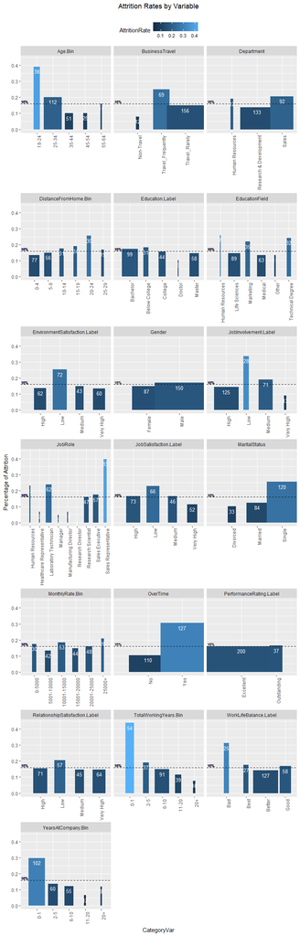

```r
## Plot
ggplot(data = attrition_data, mapping = aes(x = CategoryVar, y = AttritionRate, width=AttritionCount/100,  fill = AttritionRate)) +
  geom_bar(stat="identity", position="identity") +
  scale_colour_gradient2(low = "red", mid = "white",  high = "blue", midpoint = 0, space = "Lab",  na.value = "grey50", guide = "colourbar") +
#  scale_fill_gradient(low='darkgreen', mid='snow3', high='red', space='Lab') +
  geom_hline(yintercept = .16, linetype="dashed", size = .5)+
  geom_text(aes(0,.16,label = "16%", vjust = -.2, hjust = -.1), size=2.5) +
  geom_text(aes(label=AttritionCount), vjust=1.6, color="white", size=3.5) +
  ylab("Percentage of Attrition") +
  facet_wrap(~ColumnName, scales = 'free_x', ncol = 3) +
  theme(axis.text.x=element_text(angle=90,vjust=1,hjust=1), legend.position="top", plot.title = element_text(hjust = 0.5)) +
  ylab("Percentage of Attrition") +
  ggtitle("Attrition Rates by Variable\n")
```

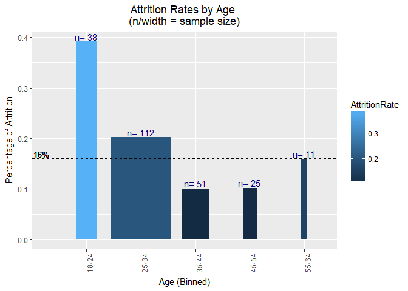

```r
age.data <- attrition_data[which(attrition_data$ColumnName == "Age.Bin"),]

ggplot(data = age.data, mapping = aes(x = CategoryVar, y = AttritionRate, width=AttritionCount/100,  fill = AttritionRate)) +
  geom_bar(stat="identity", position="identity") +
  geom_hline(yintercept = .16, linetype="dashed", size = .5)+
  geom_text(aes(0,.16,label = "16%", vjust = -.2, hjust = -.1), size=3.5) +
  geom_text(aes(label=paste("n=",AttritionCount)), vjust=-.2, color="navyblue", size=4) +
  theme(axis.text.x=element_text(angle=90,vjust=1,hjust=1), plot.title = element_text(hjust = 0.5)) +
  ylab("Percentage of Attrition") +
  xlab("Age (Binned)") +
  ggtitle("Attrition Rates by Age \n(n/width = sample size)")
```

**Analysis of Job Role**  
The second category we analyzed was Attrition Rate by Job Role. The percentage of attrition values were developed by dividing the total number of attrition in each Job Role by the total number of employees in that Job Role. The width of the bars represent the portion of the total number of attrition.  
The majority of the departed employees are Sales (Reps and Executives) and Laboratory Technicians representing nearly 64% of all departed employees.  
More in-depth analysis should focus on these three categories, with special attention on the sales organization as a whole.

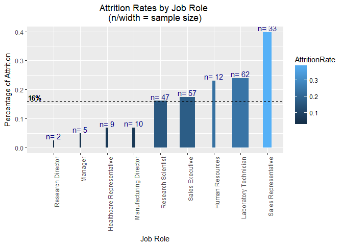

```r
jobrole <- attrition_data[which(attrition_data$ColumnName == "JobRole"),]

ggplot(data = jobrole, mapping = aes(x = reorder(CategoryVar, AttritionRate), y = AttritionRate, width=AttritionCount/100,  fill = AttritionRate)) +
  geom_bar(stat="identity", position="identity") +
  geom_hline(yintercept = .16, linetype="dashed", size = .5)+
  geom_text(aes(0,.16,label = "16%", vjust = -.2, hjust = -.1), size=3.5) +
  geom_text(aes(label=paste("n=",AttritionCount)), vjust=-.2, color="navyblue", size=4) +
  theme(axis.text.x=element_text(angle=90,vjust=1,hjust=1), plot.title = element_text(hjust = 0.5)) +
  ylab("Percentage of Attrition") +
  xlab("Job Role") +
  ggtitle("Attrition Rates by Job Role \n(n/width = sample size)")
```

**Analysis of Job Involvement**  
The next category analyzed was Attrition Rate by Job Involvement. The percentage of attrition values were developed by dividing the total number of separated employee’s corresponding Job Involvement score by the total number employee with corresponding Job Involvement scores. The width of the bars represent the portion of the total number of separated employees.  
The majority of the departed employees had High or Medium Job Involvement scores. Of the Low Job Involvement scores, nearly 34% departed the company.  
More in depth analysis should focus on how these score were developed and how bias may have played a role in the results.

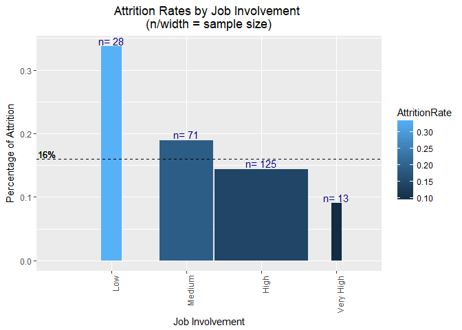

```r
job.involvement <- attrition_data[which(attrition_data$ColumnName == "JobInvolvement.Label"),]

job.involvement <- cbind(job.involvement, sortorder = c(3,1,2,4))

ggplot(data = job.involvement, mapping = aes(x = reorder(CategoryVar, sortorder), y = AttritionRate, width=AttritionCount/100,  fill = AttritionRate)) +
  geom_bar(stat="identity", position="identity") +
  geom_hline(yintercept = .16, linetype="dashed", size = .5)+
  geom_text(aes(0,.16,label = "16%", vjust = -.2, hjust = -.1), size=3.5) +
  geom_text(aes(label=paste("n=",AttritionCount)), vjust=-.2, color="navyblue", size=4) +
  theme(axis.text.x=element_text(angle=90,vjust=1,hjust=1), plot.title = element_text(hjust = 0.5)) +
  ylab("Percentage of Attrition") +
  xlab("Job Involvement") +
  ggtitle("Attrition Rates by Job Involvement \n(n/width = sample size)")
```

#### Interesting Trends

**Job Involvement vs Satisfaction**  
An analysis of categorical factors Job Involvement scores for employees vs the same employees Job Satisfaction scores, to see how they related to each other.

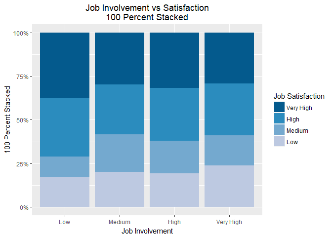

```r
Job.Sat.vs.Inv <- TalentData[,c("JobInvolvement", "JobSatisfaction", "JobInvolvement.Label", "JobSatisfaction.Label", "EmployeeCount")]

ggplot(Job.Sat.vs.Inv,aes(x = reorder(JobInvolvement.Label, JobInvolvement), y = EmployeeCount,fill = reorder(JobSatisfaction.Label, -JobSatisfaction))) +
  geom_bar(position = "fill",stat = "identity") +
  scale_fill_manual(values=c("#045a8d", "#2b8cbe", "#74a9cf", "#bdc9e1")) +
  xlab("Job Involvement") +
  ylab("100 Percent Stacked") +
  ggtitle("Job Involvement vs Satisfaction\n100 Percent Stacked") +
  theme(plot.title = element_text(hjust = 0.5)) +
  scale_y_continuous(labels = percent_format()) +
  labs(fill="Job Satisfaction")
```

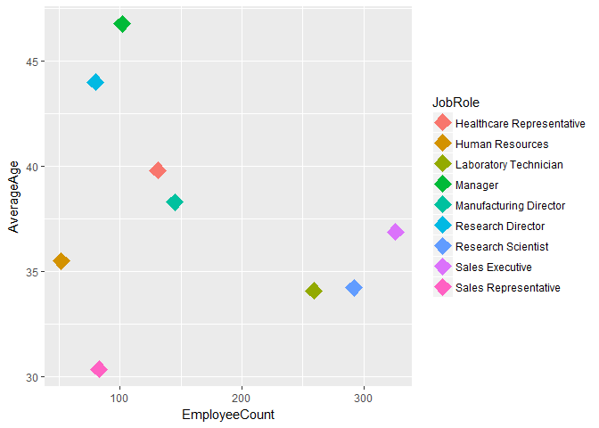

```r
JobRole.Avg.Age <-
  TalentData[,c("JobRole", "Age", "EmployeeCount")] %>%
  dplyr::group_by(JobRole) %>%
  dplyr::summarise(EmployeeCount = sum(EmployeeCount), AverageAge = mean(Age))


ggplot(data=JobRole.Avg.Age, aes(x=EmployeeCount, y=AverageAge, color=JobRole, fill=JobRole)) +
  geom_point(size=5, shape=23)
```

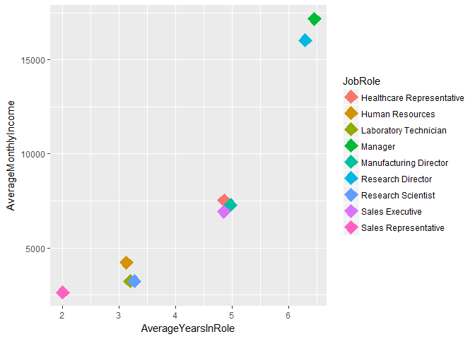

```r
JobRole.YearsvsIncome <-
  TalentData[,c("JobRole", "YearsInCurrentRole", "MonthlyIncome")] %>%
  dplyr::group_by(JobRole) %>%
  dplyr::summarise(AverageMonthlyIncome = mean(MonthlyIncome), AverageYearsInRole = mean(YearsInCurrentRole))


ggplot(data=JobRole.YearsvsIncome, aes(x=AverageYearsInRole, y=AverageMonthlyIncome, color=JobRole, fill=JobRole)) +
  geom_point(size=5, shape=23)
```

**Compensation**  
A review of compensation level for separated employees versus current employees with the same Job Roles. There does not appear to be any pattern in regards to separated employees having differing Monthly income versus other employees in same Job Role. Further investigation is required to determine if Monthly Income for these Job Roles is within industry standards.

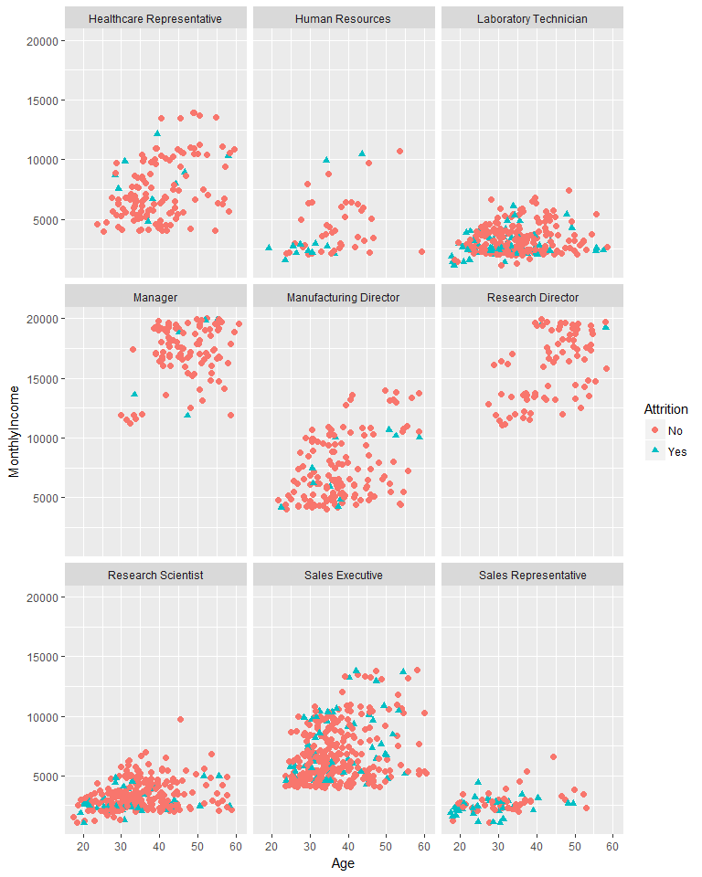

```r
Employee.Performance <- TalentData[,c("EmployeeNumber", "Age", "MonthlyIncome", "JobRole", "Attrition")]

Employee.Performance$Age <- jitter(Employee.Performance$Age, factor = 3, amount = NULL)


ggplot(data=Employee.Performance, aes(x=Age, y=MonthlyIncome, shape = Attrition, color=Attrition, fill=Attrition)) +
  geom_point(size=2) + facet_wrap(~JobRole)
```

#### Conclusion / Next Steps

As DDSAnalytics moves forward with a project to predict employee turnover, a statistical analysis must be performed to determine the significance of the findings. DDSAnalytics must also define income variables that can be used interchangeably and have an intuitive understanding (i.e. multiplying hourly rate by hours worked equals daily rate).  
Additional variables should also be considered, such as reason for attrition, which may include but not be limited to: Retirement, Career Change, Salary, Termination, RIFs. Employee Exit surveys might be helpful to pin-point reason for employees voluntarily departed the company. DDSAnalytcis should also review the way employee surveys are built and administered in order to limit any biases that may exist. The creation of a predictive model is a logical next step, but DDSAnalytics can also start building an infrastructure for machine learning and prescriptive analytic, which will be natural progressions as it expands upon its use of Data Science.